title: “Flux at Synoptic Points”

author: “Chloe”

date: “8/12/2019”

output: html_document

## Plots and Analysis

Synoptic flux vs velocity 8-12-2019,

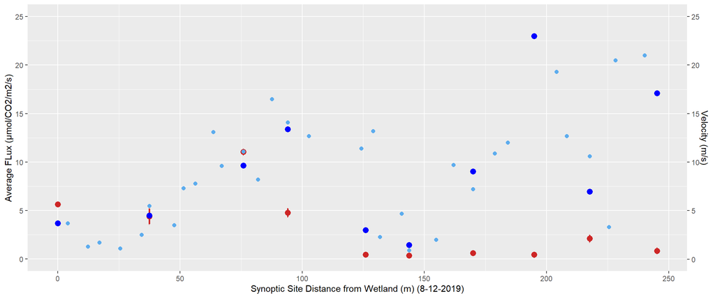

velocity vs flux 8-12-2019

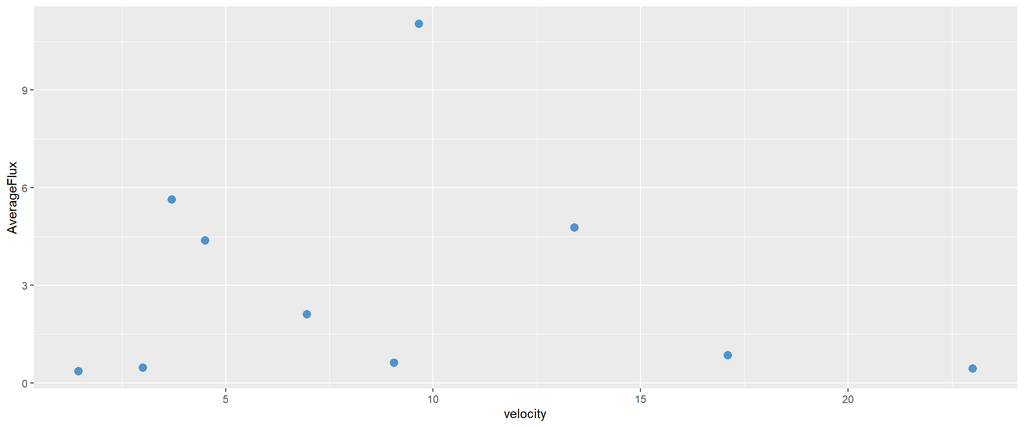

Synoptic flux paired with velocity 8-6-2019, light blue points are velocities measured between each site, dark blue points are velocity of synoptic sites found from interpolation, red is flux.

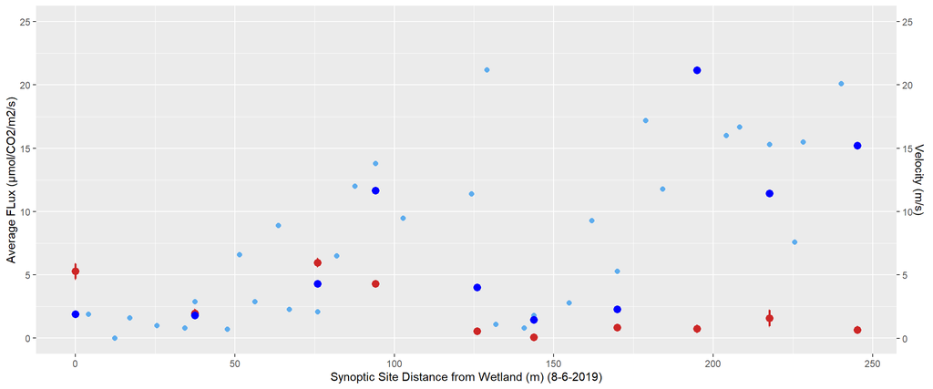

velocity vs flux 8-6-2019

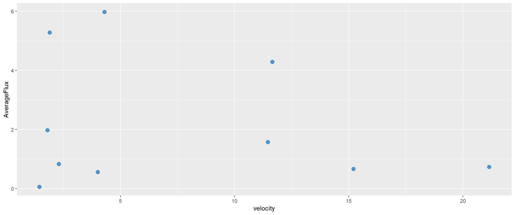

Synoptic flux paired with velocity 7-31-2019, light blue points are velocities measured between each site, dark blue points are velocity of synoptic sites found from interpolation, red is flux.

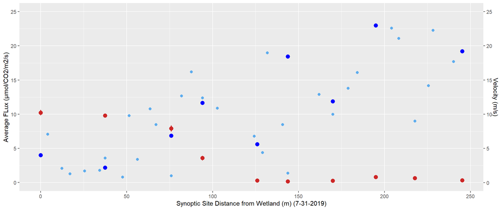

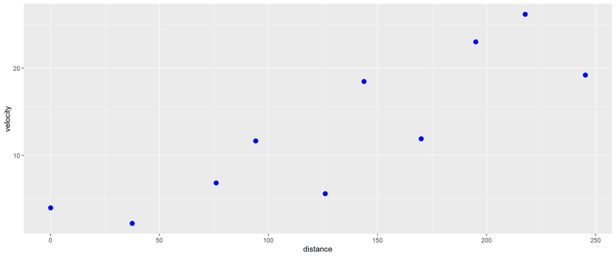

velocity vs flux 7-31-2019

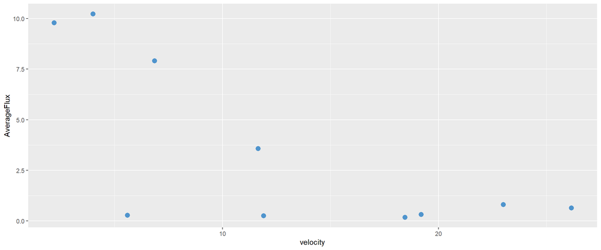

Synoptic flux paired with velocity 07-25-2019, light blue points are velocities measured between each site, dark blue points are velocity of synoptic sites found from interpolation, red is flux.

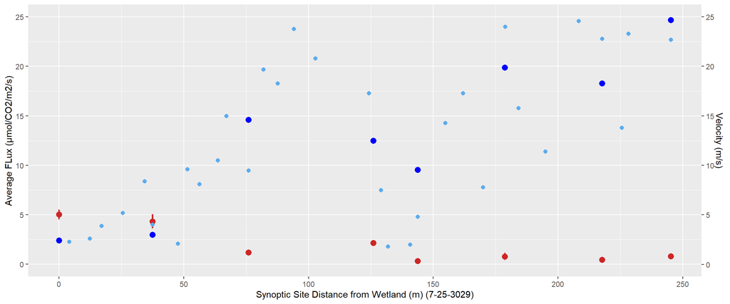

velocity vs flux 7-25-2019

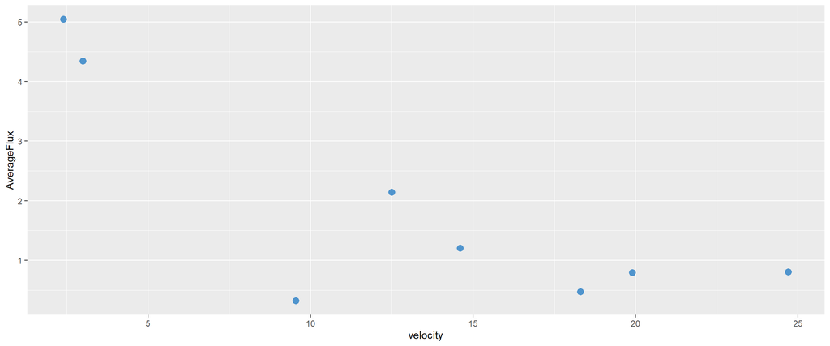

Synoptic flux paired with velocity 7-18-2019, light blue points are velocities measured between each site, dark blue points are velocity of synoptic sites found from interpolation, red is flux.

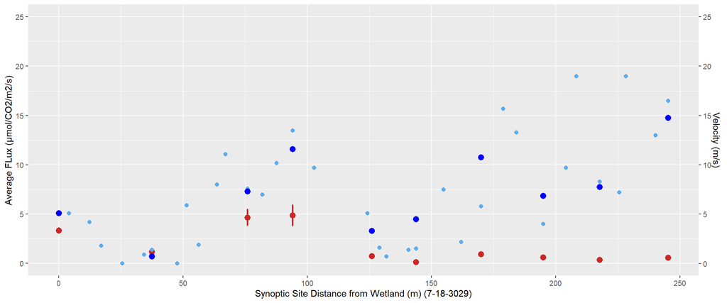

velocity vs flux 7-18-2019

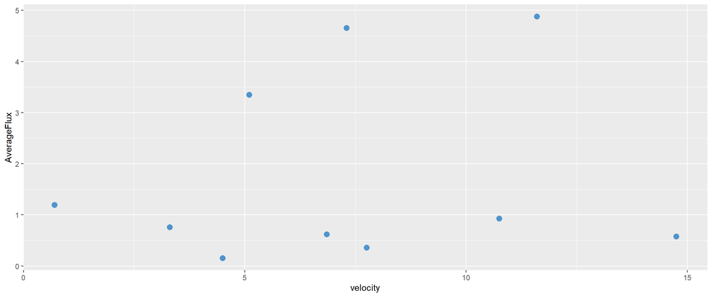

Individual Synoptic days

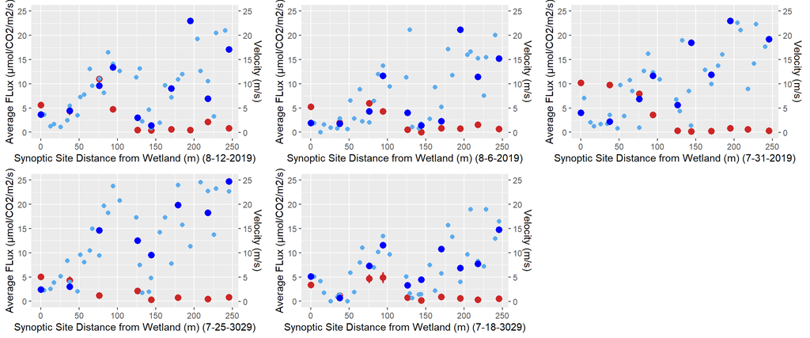

```

Combined Synoptic Day Flux Data

|  | Flux0812 | Flux0806 | Flux0731 | Flux0718 |
| --- | --- | --- | --- | --- |
| syn35 | 5.646667 | 5.277500 | 10.2250 | 3.3500 |
| syn29 | 4.392500 | 1.977500 | 9.7925 | 1.1950 |
| syn23 | 11.040000 | 5.975000 | 7.9175 | 4.6575 |
| syn20 | 4.787500 | 4.287500 | 3.5825 | 4.8800 |
| waterfall | 0.475000 | 0.565000 | 0.2925 | 0.7575 |
| syn14 | 0.362500 | 0.060000 | 0.1800 | 0.1525 |
| syn11 | 0.623750 | 0.835000 | 0.2650 | 0.9300 |
| syn8 | 0.452500 | 0.740000 | 0.8125 | 0.6200 |
| syn 5 | 2.115000 | 1.579694 | 0.6525 | 0.3600 |
| syn1 | 0.857500 | 0.665000 | 0.3225 | 0.5780 |

Averages and Standard Deviation of Synoptic Locations of 4 Synoptic Days

|  | AverageFlux | StdDev | dis |
| --- | --- | --- | --- |
| syn35 | 6.1247917 | 2.9130559 | 0.0 |
| syn29 | 4.3393750 | 3.8817926 | 37.4 |
| syn23 | 7.3975000 | 2.7730436 | 75.9 |
| syn20 | 4.3843750 | 0.5945705 | 94.1 |
| waterfall | 0.5225000 | 0.1933800 | 126.0 |
| syn14 | 0.1887500 | 0.1266968 | 143.7 |
| syn11 | 0.6634375 | 0.2948541 | 169.9 |
| syn8 | 0.6562500 | 0.1573279 | 194.9 |
| syn 5 | 1.1767985 | 0.8133461 | 217.6 |
| syn1 | 0.6057500 | 0.2220280 | 245.2 |

Velocity of each synoptic section

|  | point | Dist…m. | jul18V | jul25V | jul31V | aug6V | aug12V | Distance |
| --- | --- | --- | --- | --- | --- | --- | --- | --- |
| 1 | 34 to 35 | 4.00200 | 5.1 | 2.3 | 7.1 | 1.9 | 3.7 | 4.0020 |
| 2 | 33 to 34 | 8.33500 | 4.2 | 2.6 | 2.1 | 0.0 | 1.3 | 12.3370 |
| 3 | 32 to 33 | 4.62000 | 1.8 | 3.9 | 1.3 | 1.6 | 1.7 | 16.9570 |
| 4 | 31 to 32 | 8.53800 | 0.0 | 5.2 | 1.7 | 1.0 | 1.1 | 25.4950 |
| 5 | 30 to 31 | 8.76100 | 0.9 | 8.4 | 1.8 | 0.8 | 2.5 | 34.2560 |
| 6 | 29 to 30 | 3.18600 | 1.4 | 4.0 | 3.6 | 2.9 | 5.5 | 37.4420 |
| 7 | 28 to 29 | 10.15100 | 0.0 | 2.1 | 0.8 | 0.7 | 3.5 | 47.5930 |
| 8 | 27 to 28 | 3.88400 | 5.9 | 9.6 | 9.8 | 6.6 | 7.3 | 51.4770 |
| 9 | 26 to 27 | 4.76600 | 1.9 | 8.1 | 3.4 | 2.9 | 7.8 | 56.2430 |
| 10 | 25 to 26 | 7.41600 | 8.0 | 10.5 | 10.8 | 8.9 | 13.1 | 63.6590 |
| 11 | 24 to 25 | 3.36400 | 11.1 | 15.0 | 8.5 | 2.3 | 9.6 | 67.0230 |
| 12 | 23 to 24 | 8.90200 | 7.6 | 9.5 | 1.0 | 2.1 | 11.1 | 75.9250 |
| 13 | 22 to 23 | 5.94600 | 7.0 | 19.7 | 12.7 | 6.5 | 8.2 | 81.8710 |
| 14 | 21 to 22 | 5.79300 | 10.2 | 18.3 | 16.2 | 12.0 | 16.5 | 87.6640 |
| 15 | 20 to 21 | 6.47600 | 13.5 | 23.8 | 12.4 | 13.8 | 14.1 | 94.1400 |
| 16 | 19 to 20 | 8.61300 | 9.7 | 20.8 | 10.9 | 9.5 | 12.7 | 102.7530 |
| 17 | 18 to 19 | 21.47600 | 5.1 | 17.3 | 6.8 | 11.4 | 11.4 | 124.2290 |
| 18 | 17 to 18 | 4.73100 | 1.6 | 7.5 | 4.4 | 21.2 | 13.2 | 128.9600 |
| 19 | 16 to 17 | 2.88900 | 0.7 | 1.8 | 19.0 | 1.1 | 2.3 | 131.8490 |
| 20 | 15 to 16 | 8.78900 | 1.4 | 2.0 | 8.5 | 0.8 | 4.7 | 140.6380 |
| 21 | 14 to 15 | 3.04200 | 1.5 | 4.8 | 1.4 | 1.8 | 0.9 | 143.6800 |
| 22 | 13 to 14 | 11.11400 | 7.5 | 14.3 | 35.5 | 2.8 | 2.0 | 154.7940 |
| 23 | 12 to 13 | 7.15600 | 2.2 | 17.3 | 12.9 | 9.3 | 9.7 | 161.9500 |
| 24 | 11 to 12 | 7.99600 | 5.8 | 7.8 | 10.0 | 5.3 | 7.2 | 169.9460 |
| 25 | 10 to 11 | 8.78700 | 15.7 | 24.0 | 13.8 | 17.2 | 10.9 | 178.7330 |
| 26 | 9 to 10 | 5.34800 | 13.3 | 15.8 | 16.1 | 11.8 | 12.0 | 184.0810 |
| 27 | 8 to 9 | 10.83000 | 4.0 | 11.4 | 29.7 | 26.3 | 26.7 | 194.9110 |
| 28 | 7 to 8 | 9.18500 | 9.7 | 26.0 | 22.6 | 16.0 | 19.3 | 204.0960 |
| 29 | 6 to 7 | 4.09400 | 19.0 | 24.6 | 21.1 | 16.7 | 12.7 | 208.1900 |
| 30 | 5 to 6 | 9.42000 | 8.3 | 22.8 | 9.0 | 15.3 | 10.6 | 217.6100 |
| 31 | 4 to 5 | 7.93000 | 7.2 | 13.8 | 14.2 | 7.6 | 3.3 | 225.5400 |
| 32 | 3 to 4 | 2.65400 | 19.0 | 23.3 | 22.3 | 15.5 | 20.5 | 228.1940 |
| 33 | 2 to 3 | 11.91100 | 13.0 | 26.7 | 17.7 | 20.1 | 21.0 | 240.1050 |
| 34 | 1 to 2 | 5.10045 | 16.5 | 22.7 | 19.2 | 15.2 | 17.1 | 245.2055 |